# Plotting

Mingchu Xu

2020-01-07

### Plotting dimension reductions

Dimension reductions can be plotted by function `plot_scdata`:

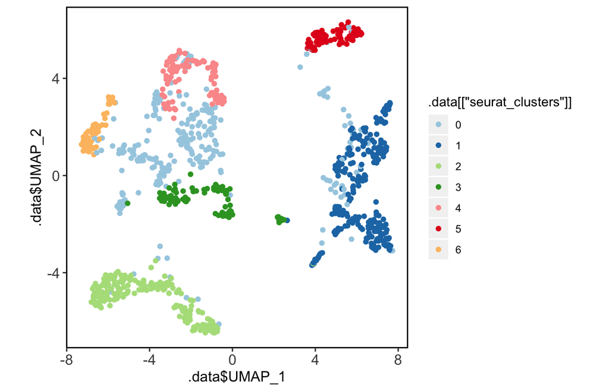

UMAP plotting, colored by clusters

```r
plot_scdata(scRNA_int, pal_setup = pal)
```

There are 3 optional arguments for `plot_scdata`: `color_by`, `split_by`, and `pal_setup`. As for the `color_by` argument, the function will color different `"seurat_clusters"` by default, and it can be changed to any factors in the metadata, like `"sample"` or `"group"`:

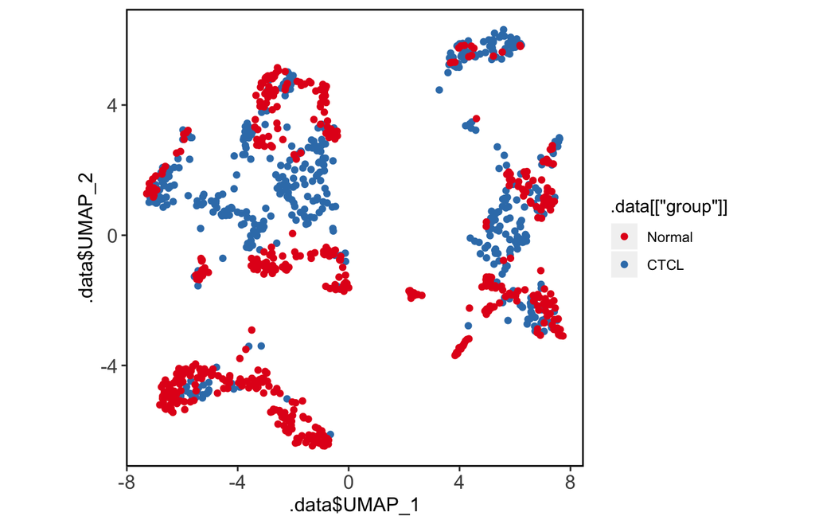

UMAP plotting, colored by groups

```r
plot_scdata(scRNA_int, color_by = "group", pal_setup = pal)
```

If `split_by` argument is specified as a factor in the metadata, the plotting will be split by that factor:

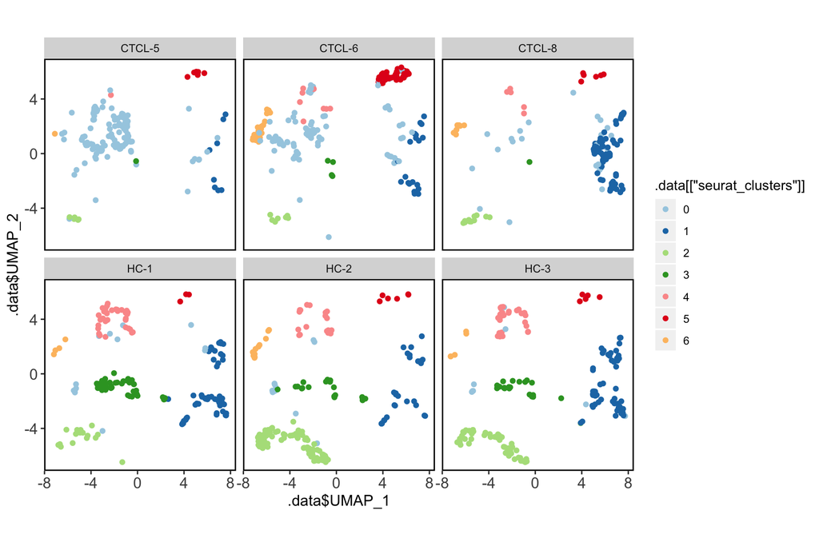

UMAP plotting, split by samples

```r
plot_scdata(scRNA_int, split_by = "sample", pal_setup = pal)
```

Similar to `plot_qc` function, the `pal_setup` argument will be useful if there is a specified palette setup to ensure consistent color scheme in different plotting functions.

### Plotting statistics

The count and proportion statistics of clustering can be plotted by function `plot_stat`, the `plot_type` argument must be provided as one of the four values: `"group_count"`, `"cluster_count"`, `"prop_fill"`, and `"prop_multi"`. Their plots are shown below:

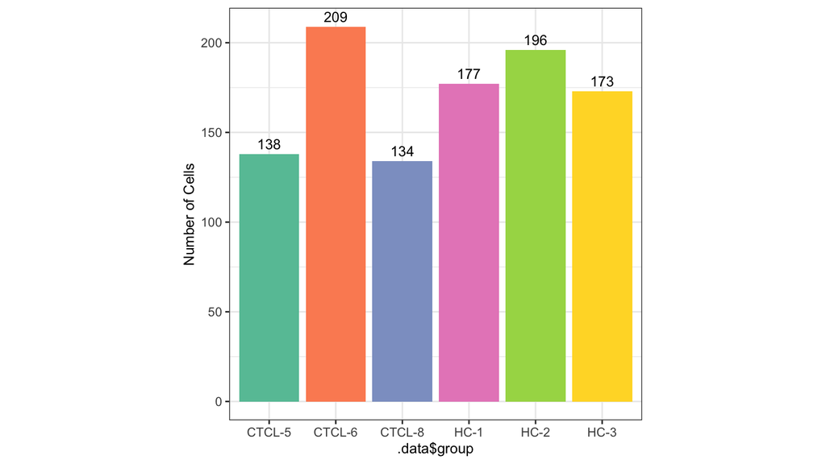

```r
plot_stat(scRNA_int, plot_type = "group_count")
```

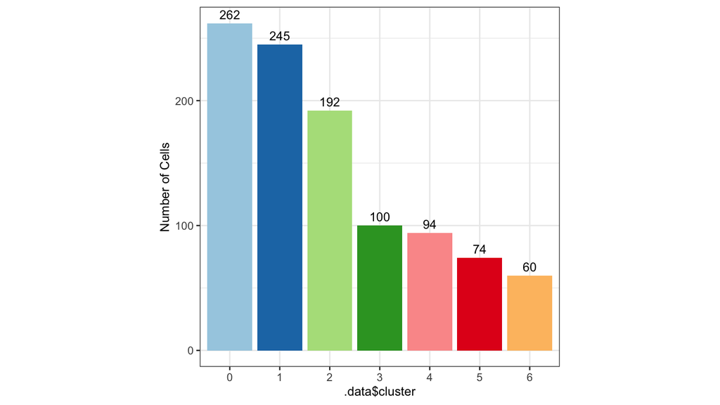

```r
plot_stat(scRNA_int, plot_type = "cluster_count")
```

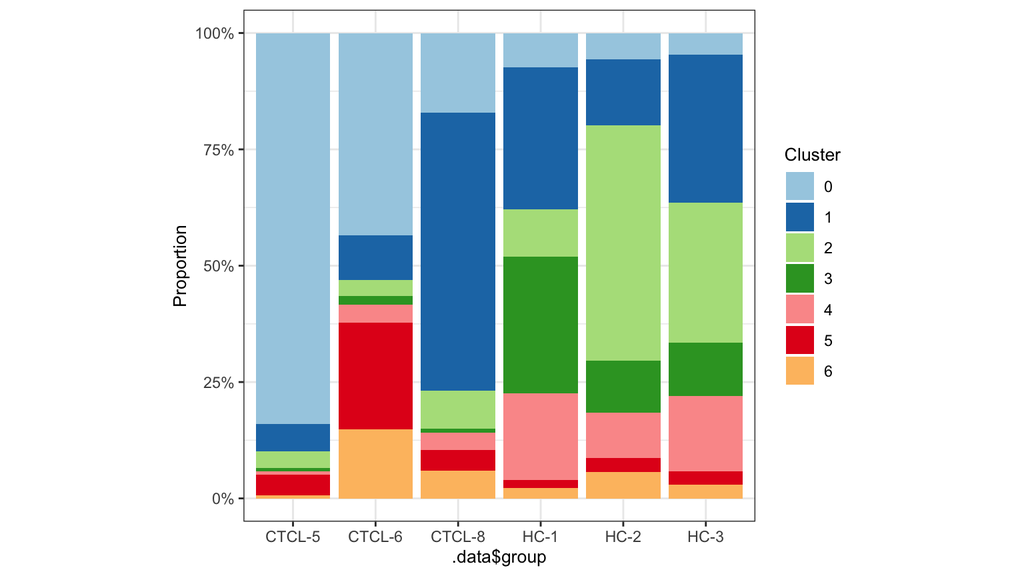

```r
plot_stat(scRNA_int, plot_type = "prop_fill")
```

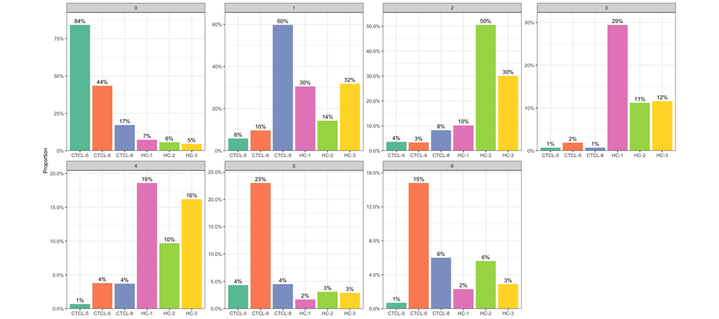

```r
plot_stat(scRNA_int, plot_type = "prop_multi")
```

The `group_by` argument uses `"sample"` as the default grouping variable, and it can be specified as other factors in the metadata (e.g. `"group"`), when `plot_type` is `group_count`, `prop_fill`, or `prop_multi`.

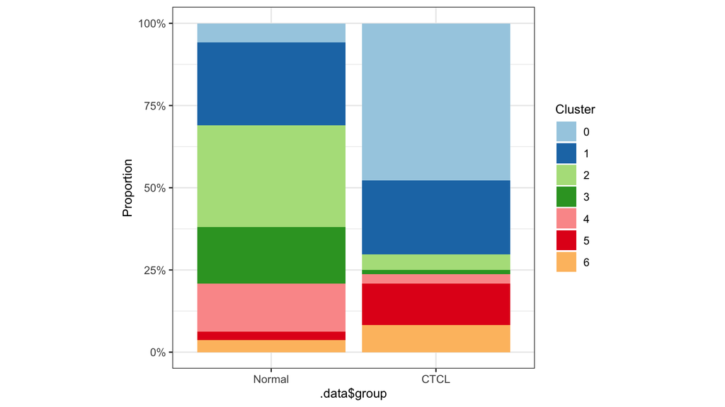

```r
plot_stat(scRNA_int, plot_type = "prop_fill", group_by = "group")
```

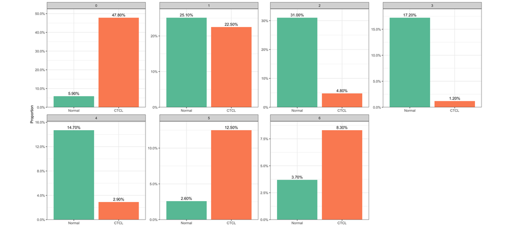

```r
plot_stat(scRNA_int, plot_type = "prop_multi", group_by = "group")
```

### Plotting heatmap

The plotting of heatmap requires cluster markers to be found by Seurat:

```r
markers <- FindAllMarkers(scRNA_int, logfc.threshold = 0.1, min.pct = 0, only.pos = T)
```

Then, the top genes in each cluster are plotted by `plot_heatmap`.

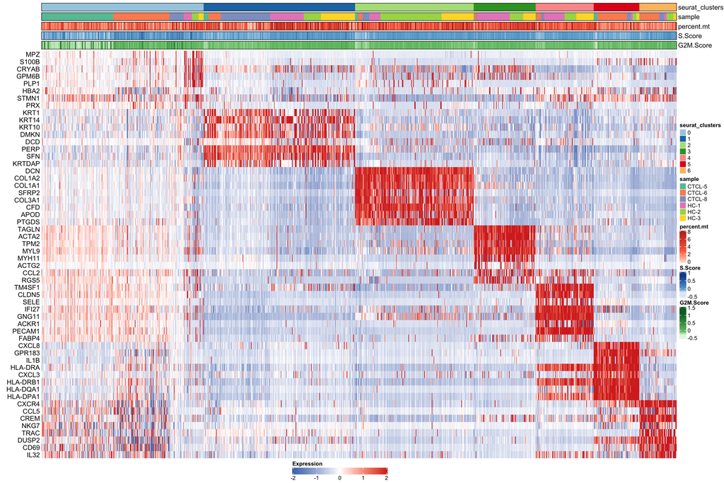

```r
plot_heatmap(dataset = scRNA_int,
              markers = markers,
              sort_var = c("seurat_clusters","sample"),
              anno_var = c("seurat_clusters", "sample","percent.mt","S.Score","G2M.Score"),
              anno_colors = c("Paired","Set2","Reds","Blues","Greens"))
```